# PracaDomowa2

Paulina Przybyłek

25 października 2019

## Wstęp do pracy

Wykres orginalny dotyczy akcji amerykańskich i skierowany jest do inwestorów. Artykuł ze strony:

https://www.parkiet.com/Analizy/310159957-WykresDnia-Zyskowne-sektory-z-SP-500.html

opisuje zmiany cen akcji od początku roku 2019. Jak można zauważyć są tam dwa wykresy przedstawiające dane po 1 tygodniu roku oraz po 7 pażdziernika. Jeśli interesuje nas dany sektor i jego zmiany to musimy szukać wartości na dwóch osiach, dodatkowo, tekst jest pionowo co utrudnia czytanie. Poniżej wykres zrobiony przez kolegę tydzień temu:

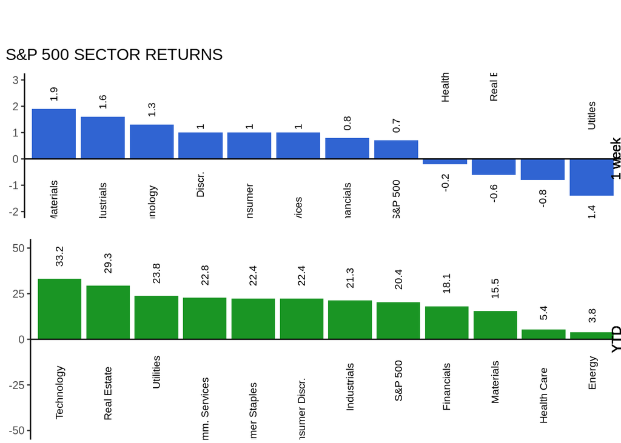

## Dlaczego ten wykres?

- Wykres ma błędy powstałe przy wprowadzaniu sektorów akcyjnych (np. na pierwszym wykresie jeden sektor złożony z dwóch wyrazów, tworzy dwa oddzielne po jednym wyrazie) - oba wykresy zawierają te same dane, a przez błędy w pisowni tak nie jest (np. na pierwszym wykresie zapomniano o jednym sektorze, na drugim są błędnie napisane nazwy niektórych sektorów)
- Podpisy na osiach i wartości są pionowo co utrudnia odczytanie
- Niektórych nazw sektorów nie widać - zostały ucięte
- Nazwy wykresrów nachodzą na osie
- Niekoniecznie wiadomo o czym jest wykres

## Co zostanie zmienione?

Czytając artykuł ze strony dowiadujemy się że wykres jest skierowany do inwestorów, których interesuje informacja o zmianie akcji, w którą mogli zainwestować albo zainwestowali. Jak wynika z artykułu - interesuje nas zmiana akcji konkretnego sektoru, dlatego:

- pierwszą zmianą jest naniesienie obu danych na jeden wykres - skoro inwestor chce wiedzieć jak się w ciągu 10 miesięcy zmieniła cena danej akcji to niech nie musi szukać jej na obu wykresach tylko niech spojrzy na jeden i już wie jaka to zmiana (dodatkowo na orginalnym wykresie nie wiedziałam na początku że oba dotyczą tych samych danych, dopóki się im lepiej nie przyjrzałam - tutaj wszystko jest w jednym miejscu)
- zmieniamy orientację wykresu, aby czytelność była lepsza
- dane ukazane są w procentach, czego na orginalnym wykresie nie widać - dodajemy tę informację
- zachowujemy kolory - można je było zmienić, jednak w świecie reklam i przedsiębiorstwa (wedle danych z internetu) kolor zielony oznacza zysk, a niebieski stabilność, więc uznałam, że dla inwestorów są to idealne kolory
- usuwamy osie - nikt nie patrzy na oś, kiedy liczby są podane obok danego słupka, dodatkowo wcześniej były dwa wykresy i osie były potrzebne aby zauważyć, że oba wykresy ukazują wartości w innej skali - teraz jest to na jednej skali i wartości mają zachowane orginalne wysokości
- zostawiamy linię na wysokości zera aby dobrze oddzielić wartości poniżej jak i powyżej
- nadajemy legendę z dokładnym opisem po jakim czasie jest podana dana zmiana ceny akcji
- zmieniamy też tytuł, żeby od początku było wiadomo co przedstawia cały wykres
- zmieniamy też czcionkę tekstu, aby wyróżnić tytuł, a legenda i wartości mają własną inną czcionkę dla oddzielenia tego od siebie i estetyki

## Wprowadzenie danych

```r
### Dane były uprzednio wprowadzone ręcznie - poniżej fragment kodu przekopiowany i delikatnie zmieniony, zawierający wprowadzenie danych

# Ręczne przepisanie liczb i nazw z wykresu
firstWeekNumbers <-c(1.9, 1.6, 1.3, 1.0, 1.0, 1.0, 0.8, 0.7, -0.2, -0.6, -0.8, -1.4)
firstWeekValues <- c('Materials', 'Industrials', 'Technology', 'Comm. Services',
                     'Consumer Discr.', 'Energy', 'Financials', 'S&P 500',
                     'Health Care', 'Real Estate', 'Consumer Staples', 'Utilities')       #poprawiono wczytanie danych - wcześniej były błędy w pisowni                                                                                             #albo podano mniej niż powinno być danych, myśląc ze jest                                                                                                 #dobrze, rozbijajac inne dane na dwa rozne
firstWeek <- cbind(firstWeekValues, firstWeekNumbers) %>% as.data.table()

YTDNumbers <- c(33.2, 29.3, 23.8, 22.8, 22.4, 22.4, 21.3, 20.4, 18.1, 15.5, 5.4, 3.8)
YTDValues <- c("Technology", "Real Estate", "Utilities", "Comm. Services",
               "Consumer Discr.", "Consumer Staples", "Industrials", "S&P 500",
               "Financials", "Materials", "Health Care", "Energy")                       #to samo co wyzej
YTD <- cbind(YTDNumbers, YTDValues) %>% as.data.table()

# Złączenie wszystkich danych
setkey(YTD, YTDValues)
setkey(firstWeek, firstWeekValues)
data <- YTD[firstWeek]
colnames(data) <- c("YTD", "names", "firstWeek")

# Wektor liczb przekonwertujemy na numeryczny w celu wykonania przyszłych operacji
data$YTD <- as.numeric(data$YTD)
data$firstWeek <- as.numeric(data$firstWeek)

# Tworzymy tabelę, na której lepiej będzie się pracować
data <- melt(data, id.vars="names")
```

## Wykres

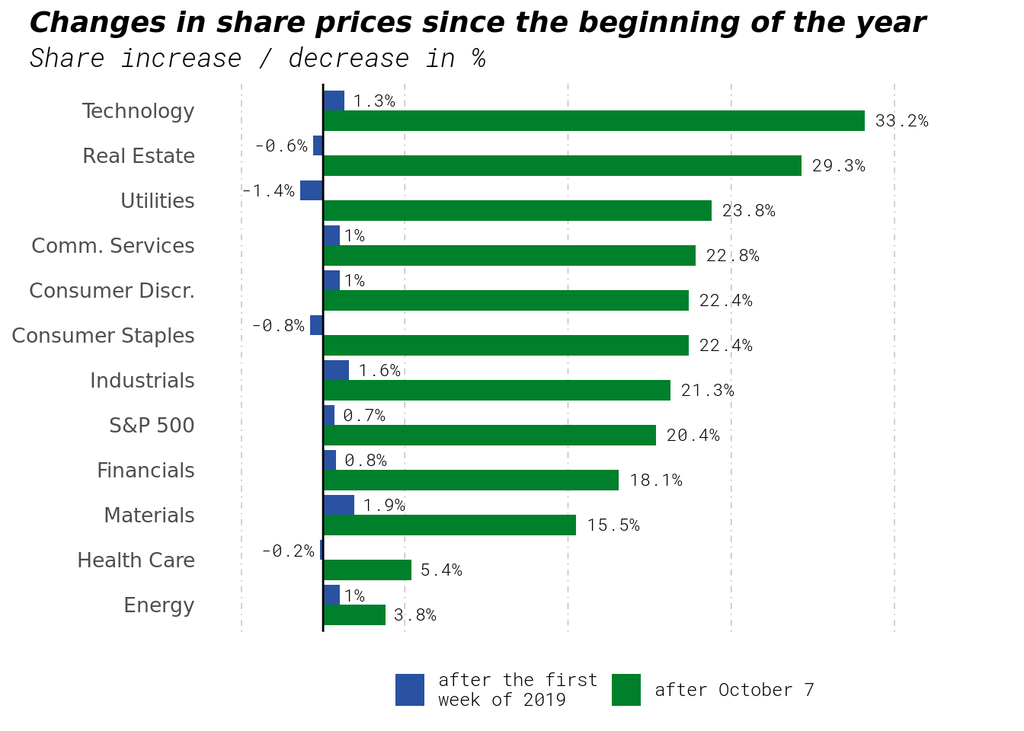

```r
### DODATKOWE DANE

# Robimy listę możliwych do wykorzystania czcionek
font <- fonts()
# Tworzymy liste do własciwego posortowania
sort <- c("Technology", "Real Estate", "Utilities", "Comm. Services",
       "Consumer Discr.", "Consumer Staples", "Industrials", "S&P 500",
       "Financials", "Materials", "Health Care", "Energy")

### WYKRES

ggplot(data, aes(x = reorder(names, match(data$names, rev(sort))), y = value, fill = variable)) +
  #chcemy zostawić barplot który dobrze ukazuje tego typu wartości, przedstwiamy je obok siebi
  geom_bar(stat="identity",
           position="dodge") +
  #białe tło
  theme_bw() +
  theme(#usuwamy kreski na osiach
        axis.ticks.x = element_blank(),
        axis.ticks.y = element_blank(),
        #usuwamy tytuł legendy
        legend.title = element_blank(),
        #zmieniamy wielkość tekstu nzw sektorow i czcionkę
        axis.text.y = element_text(size = 10,
                                   family = font[7]),
        #uswamy oś
        axis.text.x = element_blank(),
        #zmieniamy tytuł i podtytuł - odległość, wielkość, kształ i czcionkę tekstu
        plot.title = element_text(size = 14,
                                  face = "bold.italic",
                                  hjust = 2,
                                  family = font[7]),
        plot.subtitle = element_text(size = 13,
                                     hjust = -0.5,
                                     face = "italic",
                                     family = font[190]),
        #ustawiamy legednę pod wykresem na środku
        legend.position = "bottom",
        legend.justification = "center",
        #zmienamy teskt legendy
        legend.text = element_text(size = 9,
                                   family = font[190]),
        #dopracowujemy tło wykresu - linie, i ramkę
        panel.border = element_blank(),
        panel.grid.major = element_blank(),
        panel.grid.minor = element_line(colour = "grey", linetype = 4)) +
  #usuniecie nazw osi - nazwy sektorów i wartości mówią same za siebie gdy tytuł i podtylów jasno określa temat wykresu
  labs(x = NULL,
       y = NULL,
       title = "Changes in share prices since the beginning of the year",
       subtitle = "Share increase / decrease in %") +
  #zmiana zakresu osi
  scale_y_continuous(limits = c(-5, 40)) +
  #dodajemy tekst przy słupkach - chcemy aby jasno określały wartości to że są procentami
  #dodajemy tez im czcionkę
  geom_text(aes(label = paste0(value, "%")),
            hjust = ifelse(data$value < 0, 1.1, -0.2),
            vjust = ifelse(data$variable == "YTD", 1.3, -0.3),
            family = font[190],
            size = 3) +
  #nadanie lini na wysokości 0
  geom_hline(yintercept = 0) +
  #obrócenie wykresu abyuzyskać lepszą czytelność
  coord_flip() +
  #zmiana nazw w legendzie - aby bylo wiadomo po jakim czasie są to dane
  #ustawienie koloru
  scale_fill_manual(labels = c(" after October 7 ", " after the first \n week of 2019"),
                    values = c("#00802b","#2952a3")) +
  #dopieszczenie legendy np. odwrócenie kolejności
  guides(fill = guide_legend(override.aes = list(size = 1), reverse = TRUE))
```